# Introduction to `mediateR`

```r
set.seed(1234)
library(mediateR)
library(ggplot2)
library(ggfortify)
```

# 1 Data Structure

The code contains functions to simulate data for mediation analysis.

```r
params <- SimpleSim(n=10,family="gaussian")
dat <- SimulateData(params)
dat
```

```
#> $y
#>  [1] -1.779061  8.541727  5.742758  6.973347 15.811557 11.004562 -1.947651
#>  [8] -2.031084 10.377510  5.789746
#>
#> $mm
#>                  m
#>  [1,] -0.363313440
#>  [2,]  2.276360474
#>  [3,]  1.862120511
#>  [4,]  1.945054319
#>  [5,]  5.360854093
#>  [6,]  2.872684570
#>  [7,]  0.008507326
#>  [8,] -0.052420925
#>  [9,]  2.927360032
#> [10,]  1.326532724
#>
#> $xx
#>       x
#>  [1,] 0
#>  [2,] 1
#>  [3,] 1
#>  [4,] 1
#>  [5,] 1
#>  [6,] 1
#>  [7,] 0
#>  [8,] 0
#>  [9,] 1
#> [10,] 1
#>
#> $co
#>                 x
#>  [1,]  0.50605589
#>  [2,] -0.57473996
#>  [3,] -0.54663186
#>  [4,] -0.56445200
#>  [5,] -0.89003783
#>  [6,] -0.47719270
#>  [7,] -0.99838644
#>  [8,] -0.77625389
#>  [9,]  0.06445882
#> [10,]  0.95949406
#>
#> $path
#>   m
#> x 1
#>
#> $family
#> [1] "gaussian"
```

The `dat` list with named elements (y, mm, xx, co, path, family) is used as an argument for functions which estimate the direct and indirect effects. One can manually create a list with these elements (such as when fitting models to new data) or rely on the simulation function `SimulateData` to create the structure. The argument to `SimulateData` has parameters controlling the sample size, coefficient estimates, number of mediators, etc.

# 2 Data EDA

We simulate a decent sized data set for mediation analysis:

```r
params <- SimpleSim(n=1000,family="gaussian")
dat <- SimulateData(params)
dim(dat$xx)
```

```
#> [1] 1000    1
```

```r
dim(dat$mm)
```

```
#> [1] 1000    1
```

The goal is to assess the causal impact of `dat$xx` on `dat$y` and quantify how much of this effect passes through `dat$mm`. For some initial evidence, see that $x$ is correlated with both $y$ and $m$ and $m$ and $y$ are correlated:

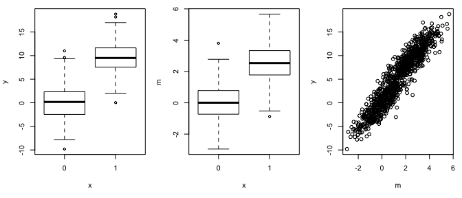

```r
par(mfcol=c(1,3),mar=c(5,4,1,1))
boxplot(dat$y~dat$xx[,1],xlab="x",ylab="y")
boxplot(dat$mm[,1]~dat$xx[,1],xlab="x",ylab="m")
plot(dat$mm,dat$y,xlab="m",ylab="y")
```

# 3 Fit Mediation Model

1. Exact path coefficients from simulation.
2. Estimated path coefficients from fitting regressions.
3. Numerical integration described in Long et al. 2019

Method 3 is not necessary in linear models (method 2 is easier), but it generalizes to non–linear models where method 2 is no longer applicable. Method 1 is only possible because this is a simulation where we know ground truth.

## 3.1 Method 1

```r
ComputeEffectsLinear(params)
```

```
#>   direct indirect total
#> x      2      7.5   9.5
#> m      3      0.0   3.0
```

## 3.2 Method 2

```r
fit <- ComputePath(dat)
ComputeEffectsLinear(fit)
```

```
#>     direct indirect    total
#> x 1.968010 7.542113 9.510123
#> m 2.979895 0.000000 2.979895
```

## 3.3 Method 3

```r
effect <- c(ComputeEffectxx(dat,fit,"direct"),
            ComputeEffectxx(dat,fit,"indirect"),
            ComputeEffectxx(dat,fit,"total"))
effect
```

```
#> [1] 1.926758 7.611707 9.457822
```

# 4 Survival Outcomes

We can also compute effects for survival models.

```r
params <- SimpleSim(n=1000,family="cox")
dat <- SimulateData(params)
class(dat$y) ## response is Surv object
```

```
#> [1] "Surv"
```

Survival curves suggest very strong effect of `dat$xx` on `dat$y`:

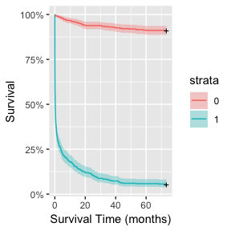

```r
fit <- survival::survfit(dat$y~as.factor(dat$xx[,1]))
autoplot(fit,xlab="Survival Time (months)",ylab="Survival")
```

Compute mediation effect point estimates:

```r
rmean <- 10
fit <- ComputePath(dat)
effect <- c("direct"=ComputeEffectxx(dat,fit,"direct",rmean=rmean),
            "indirect"=ComputeEffectxx(dat,fit,"indirect",rmean=rmean),
            "total"=ComputeEffectxx(dat,fit,"total",rmean=rmean))
effect
```

```
#>     direct   indirect      total
#> -0.4297923 -6.8972187 -7.2154837
```

Appears to be strong negative causal effect with most of this effect mediated by `dat$mm`.

## 4.1 Bootstrap Sampling to Assess Uncertainty

```r
B <- 500
boot_effect <- matrix(NA_real_,nrow=B,ncol=2)
for(ii in 1:B){
  ix <- sample(1:params$n,replace=TRUE)
  dat_boot <- mediateR:::SubsetDat(dat,ix)
  fit_boot <- ComputePath(dat_boot)
  boot_effect[ii,1] <- ComputeEffectxx(dat_boot,fit_boot,"direct",rmean=rmean)
  boot_effect[ii,2] <- ComputeEffectxx(dat_boot,fit_boot,"indirect",rmean=rmean)
}
```

Plot bootstrap samples:

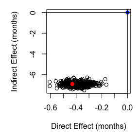

```r
par(mar=c(5,5,1,1))
plot(boot_effect[,1],boot_effect[,2],
     xlim=range(c(0,boot_effect[,1])),ylim=range(c(0,boot_effect[,2])),
     xlab="Direct Effect (months)",ylab="Indirect Effect (months)")
points(effect[1],effect[2],col='red',pch=19)
points(0,0,col='blue',pch=19)
abline(h=0)
abline(v=0)
```

Conclusion: `dat$xx` has a strong negative causal impact on survival with most of this effect passing through the mediator `dat$mm`.